# Analyse de la température maximale journalière à Londres

Timothée TEMPLIER - Samuel BALLU

```r
# Importer le fichier final_data.csv
data <- read.csv("final_data.csv")
data$YEAR <- format(as.Date(data$date), "%Y")
data$MONTH_DAY <- format(as.Date(data$date), "%m-%d")
data <- data[, c("YEAR", "MONTH_DAY", "max_temp")]

# Suppression des jours pour les années bisextile
data <- data %>%
  filter(!(substr(MONTH_DAY, 1, 2) == "02" & substr(MONTH_DAY, 4, 5) == "29"))


# maj val manquantes par la moyenne entre les deux jours précédent
data$max_temp[is.na(data$max_temp)] <- (data$max_temp[which(is.na(data$max_temp)) - 1] + data$max_temp[which(is.na(data$max_temp)) + 1]) / 2
```

# Introduction

Nous avons récupéré sur Kaggle des données météorologiques de Londres pour la période 1980-2020. Ces données comprennent plusieurs variables, dont la **température maximale** enregistrée. Pour notre analyse, nous avons divisé le jeu de données en deux périodes distinctes : 1980-2000 et 2000-2020.

Dans ce projet, nous nous concentrons sur une étude approfondie de la température maximale pour la période 2000-2020. Nous comparerons ensuite ces résultats, de manière simplifiée, avec ceux de la période 1980-2000 afin d’évaluer l’impact potentiel du réchauffement climatique.

Nous appliquerons des méthodes de traitement de signal afin de lisser les données de température maximale, pour obtenir une représentation plus continue et fluide des tendances observées.

Le jeu de données utilisé pour ce projet se compose des variables suivantes :

| Variable | Description |
| --- | --- |
| YEAR | Année de du relevé |
| MONTH_DAY | Mois et jour du relevé |
| max_temp | Température maximale atteinte durant la journée |

Afin de passer du discret au continu, nous allons ajuster les données en utilisant la **méthode des moindres carrés pénalisés** en nous appuyant sur une **base spline**. Cette approche permet de lisser le signal tout en contrôlant la complexité de la fonction ajustée. Ainsi, les oscillations excessives sont limitées, et le modèle reste fidèle aux observations initiales sans perdre en généralisabilité.

Nous avons choisi d’utiliser une **base spline** plutôt qu’une autre base, car elle excelle à capturer les variations locales, ce qui est particulièrement adapté aux signaux irréguliers comme la température. De plus, les bases spline sont adapter à modéliser des données non périodiques, ce qui correspond à nos données, où chaque individu représente une année distincte.

## Statistique descriptive

D’abord regardons à quoi ressemblent nos données. Cela nous aidera à mieux comprendre la distribution de la température. Nous voulons aussi voir si, à cause du changelent climatique, la température maximale a augmenté au fil des années.

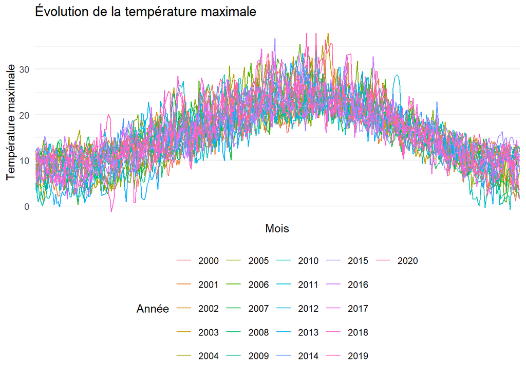

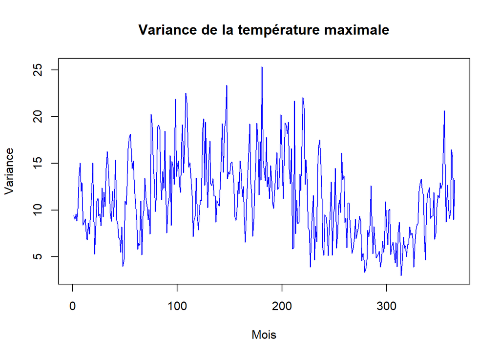

On ne remarque pas de différence flagrante entre les différentes années. Les années ont toutes un comportemnt identique : elles commencent par une température basse en janvier, puis la température augmente jusqu’à atteindre un pic en juillet, avant de redescendre. On observe une variance plus élevée dans les deux premiiers tiers des années, ce qui est cohérent avec la saisonnalité de la température.

# Transformation des données en signaux continus

## Choix de nos paramètres

Dans un premier temps nous allons essayer de parametrer les parmètres de la bases de Spline. On selectionne une année pour tester les différents pramètres.

```r
y <- data[data$YEAR == 2000,]$max_temp
```

**Test sur les ordres :**

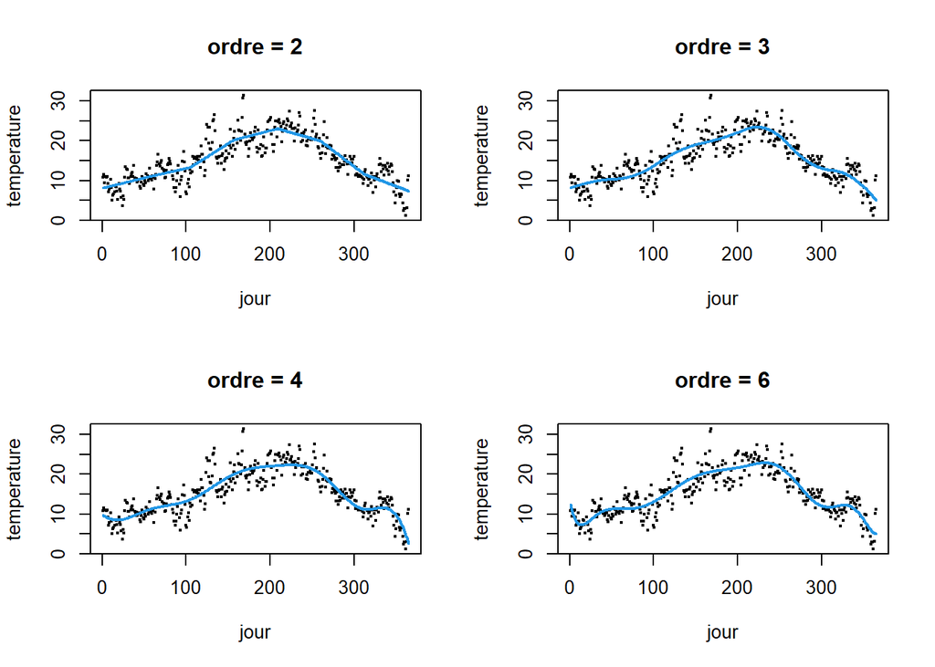

```r
norder = c(2,3,4,6)
par(mfrow=c(2,2))
for(d in norder){
  splbasis = create.bspline.basis(rangeval=c(1,365),norder=d,breaks=seq(1,365,length=8))
  chat = Data2fd(1:365,y,basisobj = splbasis)
  fhat = eval.fd(1:365,chat)
  plot(y,pch=20,cex=0.5,main=paste("ordre = ",d,sep=""),xlab="jour",ylab="temperature")
  lines(fhat,col=4,lwd=2)
}
```

On observe que la base d’ordre 2 conduit à une reconstruction non lisse (non dérivable aux points de rupture) tandis que la base d’ordre 3 ne semble pas assez flexible (difficulté à bien approcher les temperatures les plus hautes/basses). A partir de l’ordre 4, les reconstructions sont satisfaisantes.

Dans notre cas, étant donné que nous utilisons une MCO pénalisée, nous choisirons 6 nœuds, car l’effet de l’ordre est atténué par la pénalisation. Nous pouvons donc opter pour un ordre relativement élevé. Comme il n’y a pas énormément de différence entre un ordre 4 et un ordre 6, hormis aux extrémités, nous nous orienterons plutôt vers un ordre 6.

**Test nombre de noeuds :**

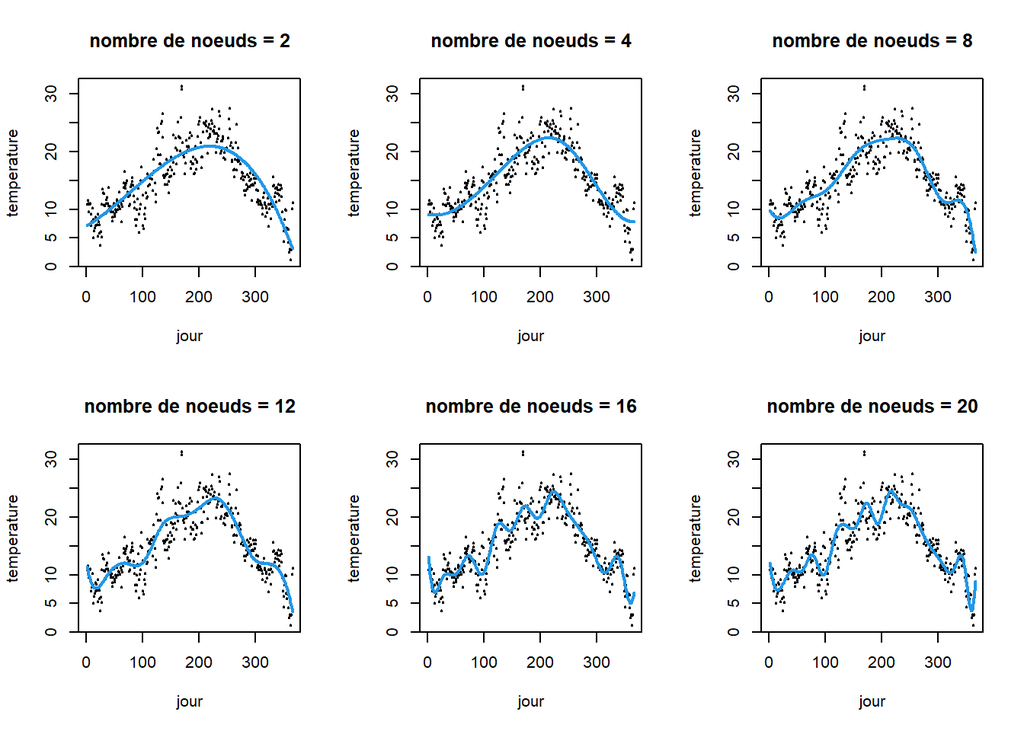

```r
noeuds = c(2,4,8,12,16,20)
par(mfrow=c(2,3))
for(l in noeuds){
  splbasis = create.bspline.basis(rangeval=c(1,365),norder=4,breaks=seq(1,365,length=l))
  chat = Data2fd(1:365,y,basisobj = splbasis)
  fhat = eval.fd(1:365,chat)
  plot(y,pch=20,cex=0.5,main=paste("nombre de noeuds = ",l,sep=""),xlab="jour",ylab="temperature")
  lines(fhat,col=4,lwd=2)
}
```

On observe que trop peu de noeuds donne une approximation biaisée (pas assez proche des données observées - underfitting) tandis que trop de noeuds donne une reconstruction “ondulante”, trop flexible (overfitting).

Comme on utilisera une MCO pénalisée on poura utiliser 20 noeud, ou plus car la pénalisation réduit la sensibilité au nombre de nœuds. Elle contrôle l’ajustement excessif en lissant automatiquement la courbe. On peut donc ce permettre d’augmenter le nombre de noeud.

## Controle de la valeur λ

On regarde la moyenne des critères gcv sur tous les individus pour chaque valeur de λ. On cherche à calibrer λ pour l’ensemble des individus

Calcul de gcv (Generalized Cross-Validation) : Le critère gvc évalue la qualité du lissage pour chaque valeur de λ. Une valeur plus faible indique un meilleur compromis entre ajustement et complexité

```r
# Creation de la matrix avec pour colonne l'année et pour ligne la demande par jour
temp_matrix <- dcast(data, MONTH_DAY ~ YEAR, value.var = "max_temp")

# Modifier les lignes pour que 'MONTH_DAY' soit l'index (et supprimer la colonne 'MONTH_DAY')
rownames(temp_matrix) <- temp_matrix$MONTH_DAY
temp_matrix <- temp_matrix[, -1]  # Supprimer la colonne 'MONTH_DAY'

temp_matrix <- as.matrix(temp_matrix)
```

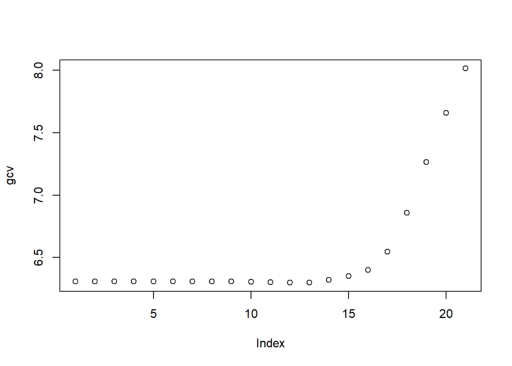

```r
splbasis365 = create.bspline.basis(c(1,365),norder=6,breaks=seq(1,365,20))
gcv = 1:21
for (i in 1:21){
  lambda = exp(i-10)
  fdparTemp = fdPar(splbasis365,Lfdobj = 2,lambda=lambda)
  smoothdata = smooth.basis(1:365,temp_matrix,fdParobj = fdparTemp)
  gcv[i] = smoothdata$gcv
}
plot(gcv)
```

```r
which.min(gcv)
```

```
## [1] 12
```

```r
lambda = exp(which.min(gcv)-10)
fdparTemp = fdPar(splbasis365,Lfdobj = 2,lambda=lambda)
smoothdata = smooth.basis(1:365,temp_matrix,fdParobj = fdparTemp)
#plotfit.fd(temp_matrix,1:365,smoothdata$fd,pch=20,cex=0.5)
```

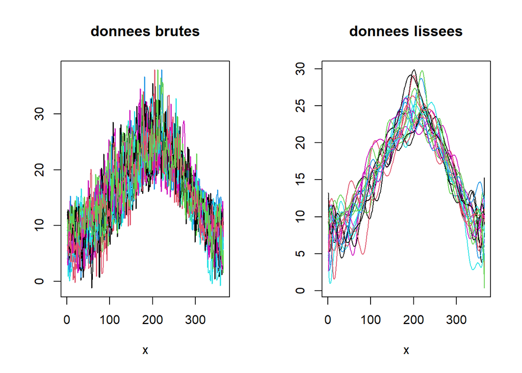

```r
fhatsmooth = eval.fd(1:365,smoothdata$fd)
par(mfrow=c(1,2))
matplot(1:365,temp_matrix,type="l",lty=1,ylab="",main="donnees brutes")
matplot(1:365,fhatsmooth,type="l",lty=1,ylab="",main="donnees lissees")
```

résidu :

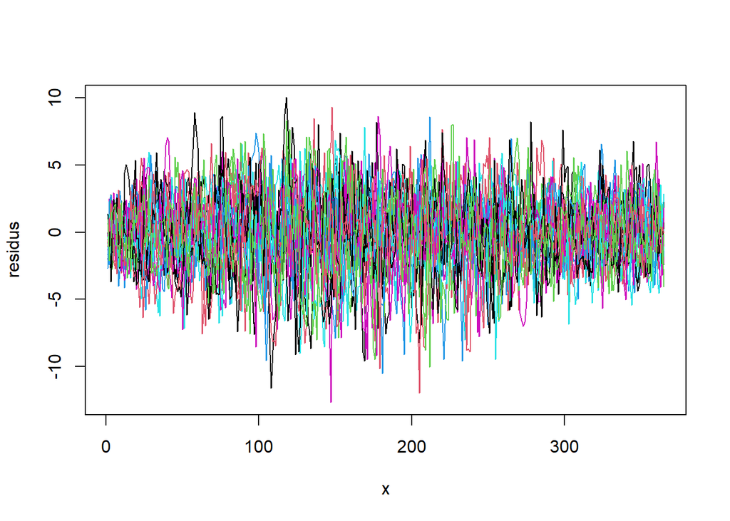

```r
matplot(1:365,fhatsmooth-temp_matrix,lty=1,type="l",ylab="residus")
```

Les résidus sont centrés autour de zéro ce qui est cohérent.

**Nouvelle base avec un noeud de 50* :**

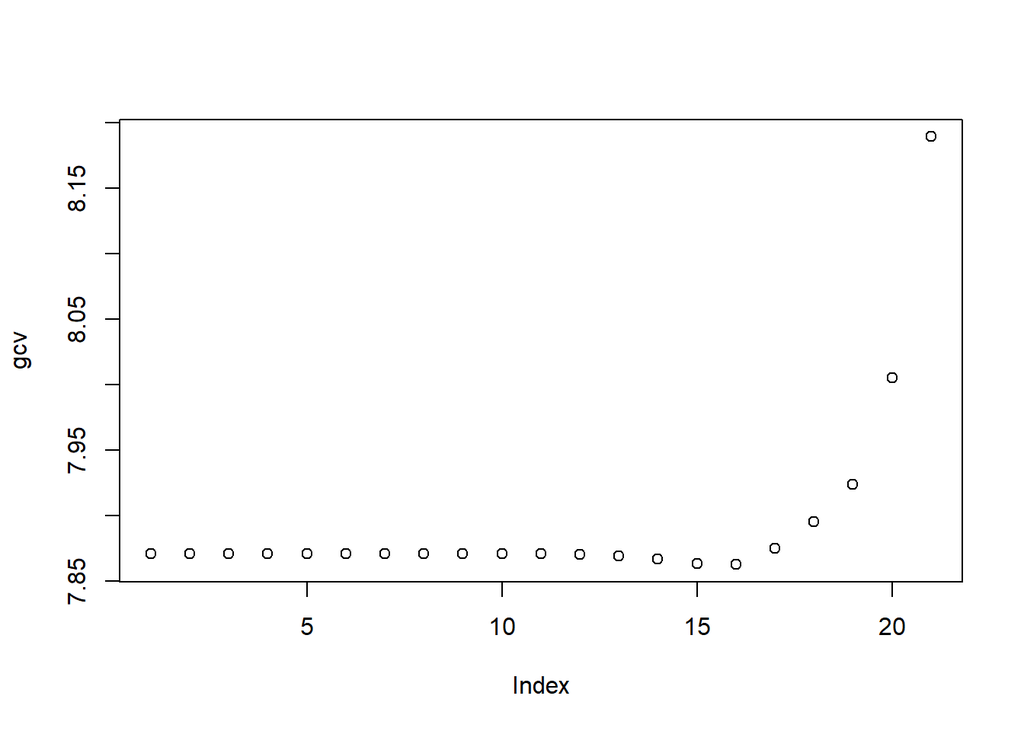

```r
splbasis365 = create.bspline.basis(c(1,365),norder=6,breaks=seq(1,365,50))
gcv = 1:21
for (i in 1:21){
  lambda = exp(i-10)
  fdparTemp = fdPar(splbasis365,Lfdobj = 2,lambda=lambda)
  smoothdata = smooth.basis(1:365,temp_matrix,fdParobj = fdparTemp)
  gcv[i] = smoothdata$gcv
}
plot(gcv)
```

```r
which.min(gcv)
```

```
## [1] 16
```

```r
lambda = exp(which.min(gcv)-10)
fdparTemp = fdPar(splbasis365,Lfdobj = 2,lambda=lambda)
smoothdata = smooth.basis(1:365,temp_matrix,fdParobj = fdparTemp)
#plotfit.fd(temp_matrix,1:365,smoothdata$fd,pch=20,cex=0.5)
```

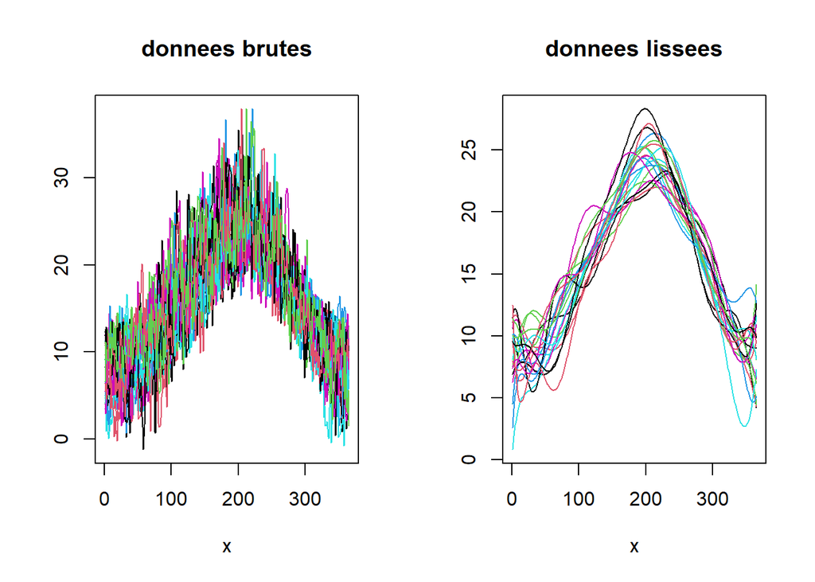

```r
fhatsmooth = eval.fd(1:365,smoothdata$fd)
par(mfrow=c(1,2))
matplot(1:365,temp_matrix,type="l",lty=1,ylab="",main="donnees brutes")
matplot(1:365,fhatsmooth,type="l",lty=1,ylab="",main="donnees lissees")
```

résidu :

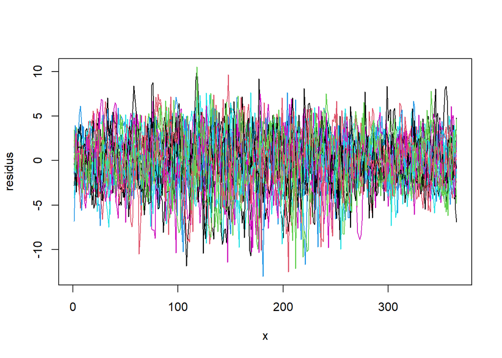

```r
matplot(1:365,fhatsmooth-temp_matrix,lty=1,type="l",ylab="residus")
```

Les résidus sont centrés autour de zéro ce qui est cohérent.

# Statistique exploratoire

## Moyenne et écart-type fonctionnels

La statistique exploratoire permet de mieux comprendre les données et de les visualiser de manière plus claire. Nous allons utiliser des méthodes de lissage pour obtenir une représentation plus continue de la température maximale journalière à Londres

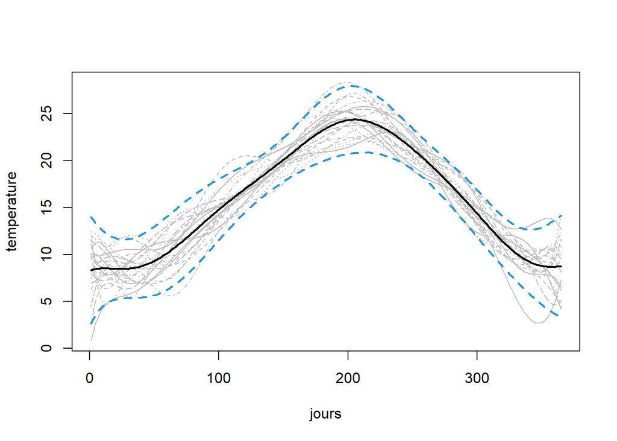

```r
meantemp = mean.fd(smoothdata$fd) #moyenne (objet fonctionnel fd)
sdtemp = sd.fd(smoothdata$fd) #ecart-type (objet fonctionnel fd)

matplot(fhatsmooth,col="gray",type="l",xlab="jours",ylab="temperature")
fnmoy = eval.fd(1:365,meantemp)
fnsd  = eval.fd(1:365,sdtemp)
lines(fnmoy,lwd=2)
lines(fnmoy+2*fnsd,lwd=2,col=4,lty=2)
lines(fnmoy-2*fnsd,lwd=2,col=4,lty=2)
```

On remarque que la température maximale est plus élevée en été qu’en hiver, ce qui est cohérent avec les saisons. On observe également une certaine régularité dans les données, avec des pics de température en été et des creux en hiver. La moyenne fonctionnelle permet de mieux visualiser cette tendance.

On observe une variabilité plus importante pour les mois d’été et d’hiver que pour ceux d’automne et de printemps. Et un forte variabilité lors du changement d’années (aux extrêmes du graphique)

## Surface de covariance et corrélation

Nous pouvons aussi analyser la surface du processus en calculant sa covariance et sa corrélation.

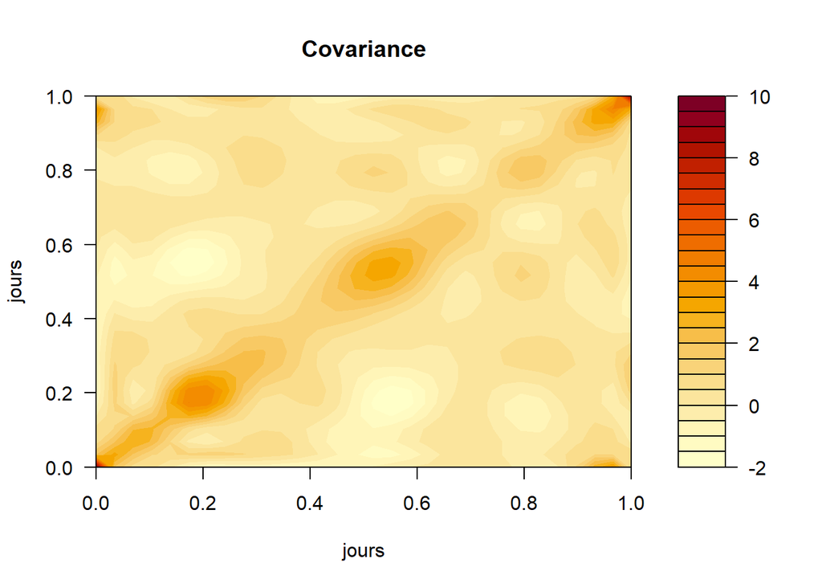

```r
par(mfrow=c(1,2))
# Covariance
covdata = var.fd(smoothdata$fd)
surfcov = eval.bifd(seq(1,365,length=30),seq(1,365,length=30),covdata)
# Corrélation
cordata = cor.fd(seq(1,365,length=30),smoothdata$fd)

filled.contour(surfcov, xlab="jours", ylab="jours", main="Covariance")
```

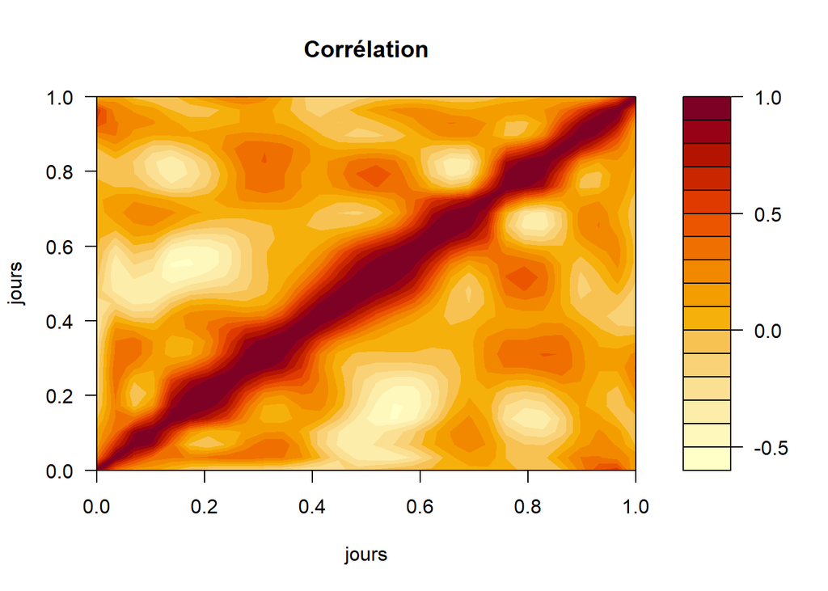

```r
filled.contour(cordata, xlab="jours", ylab="jours", main="Corrélation")
```

Les graphiques montrent les matrices de covariance et de corrélation des données fonctionnelles sur une échelle annuelle. La covariance met en évidence des variations globales, avec des zones de covariance positive et négative, suggérant que certains jours évoluent dans des directions opposées.

La matrice de corrélation révèle également des relations négatives en dehors de la diagonale principale, indiquant une anti-corrélation entre certains jours plus éloignés dans le temps. Ces résultats confirment une structure saisonnière, avec des similarités fortes à court terme et des comportements inverses possibles entre des périodes spécifiques de l’année.

## ACP fonctionnelle

```r
dataACPF = pca.fd(smoothdata$fd,nharm=6,centerfns = TRUE) # 6 fonctiosn propres, True = fonnées centrées
dataACPF$varprop
```

```
## [1] 0.27444321 0.18134685 0.15411598 0.10308847 0.08743849 0.05155546
```

```r
cumsum(dataACPF$varprop)
```

```
## [1] 0.2744432 0.4557901 0.6099060 0.7129945 0.8004330 0.8519884
```

Au vu des résultats, les 6 premières fonctions propres expliquent 85% de la variance totale. Les 5 premières fonctions propres expliquent 80% de la variance totale. On peut donc se contenter de 5 fonctions propres pour expliquer la majorité de la variance.

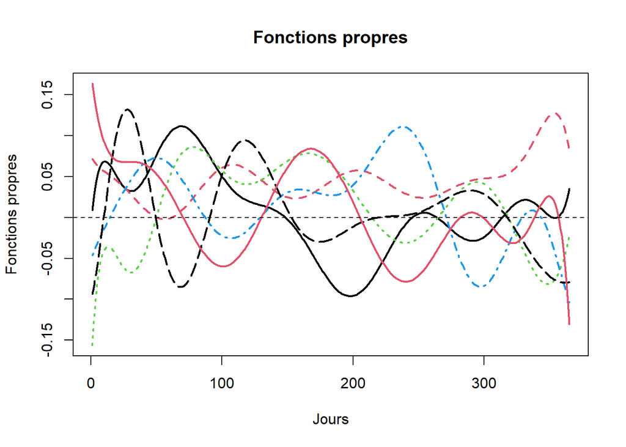

```
## [1] "done"
```

```r
plot(dataACPF$harmonics, col = 1:4, lwd = 2, xlab = "Jours", ylab = "Fonctions propres", main = "Fonctions propres")
```

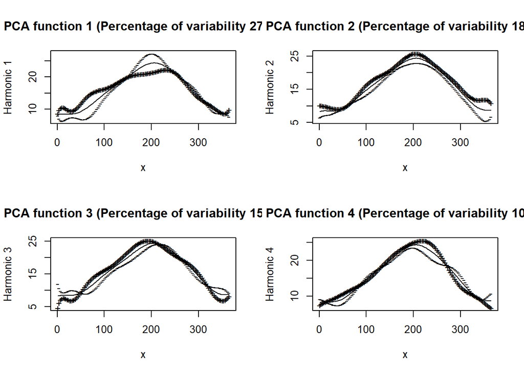

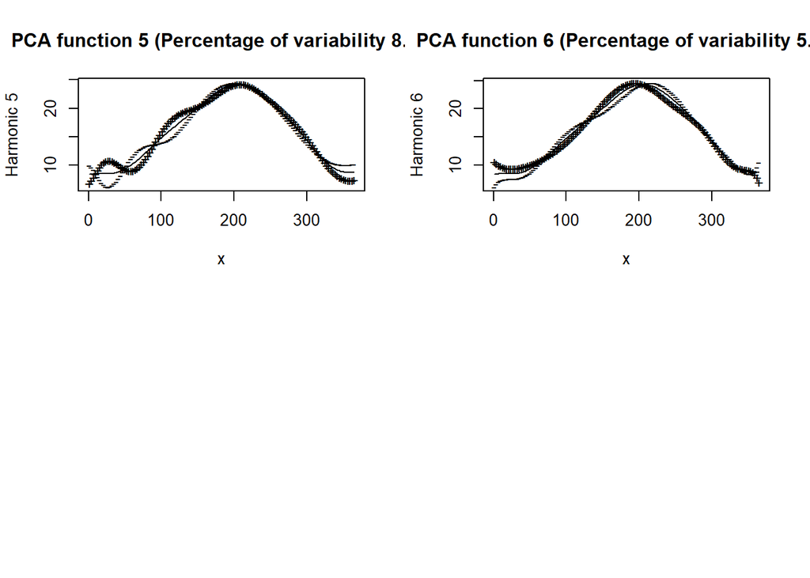

```r
par(mfrow=c(2,2))
plot.pca.fd(dataACPF)
```

Notre analyse ACP fonctionnelle montre que les deux premières composantes principales expliquent 45 % de la variabilité totale, représentant la tendance saisonnière principale et des fluctuations secondaires (variations de température). Les troisième et quatrième composantes, plus complexes, modélisent des variations locales ou des anomalies spécifiques, atteignant 70 % de la variance cumulée. Nous pouvons donc en déduire que les premières composantes capturent les principales dynamiques des données, suffisantes pour décrire leur structure globale.

## Comparaison avec les données des années 1980-2000

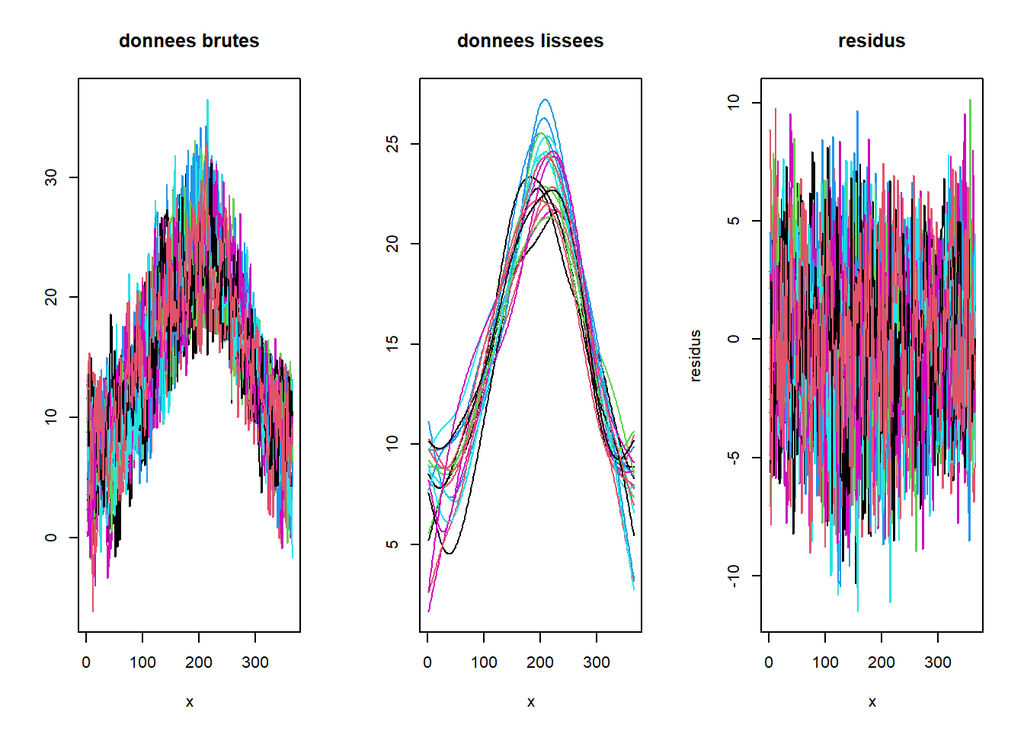

```r
data_bf <- read.csv("data/london_weather.csv", sep=",")
data_bf <- data_bf %>%
  filter(as.numeric(substr(date, 1, 4)) < 2000)
data_bf <- data_bf %>%
  filter(as.numeric(substr(date, 1, 4)) >= 1980)
data_bf$date <- as.Date(as.character(data_bf$date), format = "%Y%m%d")

data_bf$YEAR <- format(as.Date(data_bf$date), "%Y")
data_bf$MONTH_DAY <- format(as.Date(data_bf$date), "%m-%d")
data_bf <- data_bf[, c("YEAR", "MONTH_DAY", "max_temp")]

# Suppression des jours pour les années bisextile
data_bf <- data_bf %>%
  filter(!(substr(MONTH_DAY, 1, 2) == "02" & substr(MONTH_DAY, 4, 5) == "29"))

# maj val manquantes par la moyenne entre les deux jours précédent
data_bf$max_temp[is.na(data_bf$max_temp)] <- (data_bf$max_temp[which(is.na(data_bf$max_temp)) - 1] + data_bf$max_temp[which(is.na(data_bf$max_temp)) + 1]) / 2

# Creation de la matrix avec pour colonne l'année et pour ligne la demande par jour
temp_matrix_bf <- dcast(data_bf, MONTH_DAY ~ YEAR, value.var = "max_temp")

# Modifier les lignes pour que 'MONTH_DAY' soit l'index (et supprimer la colonne 'MONTH_DAY')
rownames(temp_matrix_bf) <- temp_matrix_bf$MONTH_DAY
temp_matrix_bf <- temp_matrix_bf[, -1]  # Supprimer la colonne 'MONTH_DAY'

temp_matrix_bf <- as.matrix(temp_matrix_bf)

splbasis365_bf = create.bspline.basis(c(1,365),norder=6,breaks=seq(1,365,50))
gcv_bf = 1:21
for (i in 1:21){
  lambda_bf = exp(i-10)
  fdparTemp_bf = fdPar(splbasis365_bf,Lfdobj = 2,lambda=lambda_bf)
  smoothdata_bf = smooth.basis(1:365,temp_matrix_bf,fdParobj = fdparTemp_bf)
  gcv_bf[i] = smoothdata_bf$gcv
}
#plot(gcv_bf)


fhatsmooth_bf = eval.fd(1:365,smoothdata_bf$fd)
par(mfrow=c(1,3))
matplot(1:365,temp_matrix_bf,type="l",lty=1,ylab="",main="donnees brutes")
matplot(1:365,fhatsmooth_bf,type="l",lty=1,ylab="",main="donnees lissees")
matplot(1:365,fhatsmooth_bf-temp_matrix_bf,lty=1,type="l",ylab="residus", main ="residus")
```

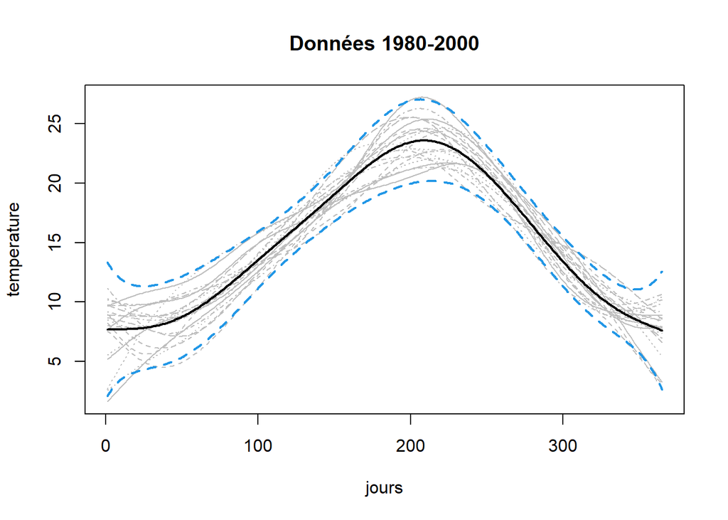

```r
par(mfrow=c(1,1))
meantemp_bf = mean.fd(smoothdata_bf$fd) #moyenne (objet fonctionnel fd)

sdtemp_bf = sd.fd(smoothdata_bf$fd) #ecart-type (objet fonctionnel fd)
matplot(fhatsmooth_bf,col="gray",type="l",xlab="jours",ylab="temperature", main = "Données 1980-2000")
fnmoy = eval.fd(1:365,meantemp_bf)
fnsd  = eval.fd(1:365,sdtemp_bf)
lines(fnmoy,lwd=2)
lines(fnmoy+2*fnsd,lwd=2,col=4,lty=2)
lines(fnmoy-2*fnsd,lwd=2,col=4,lty=2)
```

On observe également une variabilité plus importante pour les mois d’été et d’hiver, mais surtout pour l’automne et le printemps ou l’on remarque une variabilité moins important par rapport aux année 2000-2020.

De plus on observe forte variabilité lors du changement d’années (aux extrêmes du graphique). Mais celle-ci semble aussi plus faible que pour les années 2000 à 2020. On remarque que les températures maximales en été semblent atteindre 25°C tandis que pour les années 2000 à 2020 elles semblent atteindre 27°C.

Comparons les moyennes de ces deux groupes d’années pour voir si nous voyons une différence climatique entre les deux périodes.

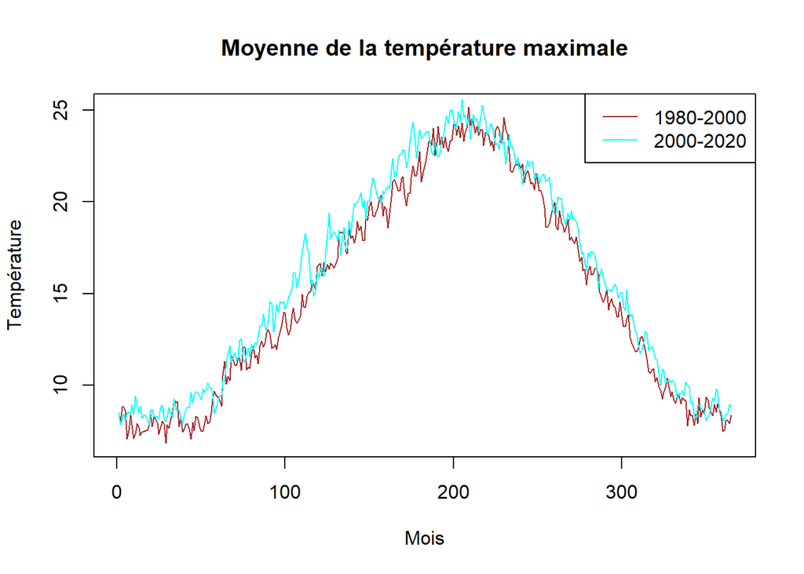

```r
moy_data_bf <- data_bf %>%
  group_by(MONTH_DAY) %>%
  summarise(MOYENNE = mean(max_temp, na.rm = TRUE))

moy_data <- data %>%
  group_by(MONTH_DAY) %>%
  summarise(MOYENNE = mean(max_temp, na.rm = TRUE))

# Affichage des deux courbes sur le même graphique
plot(moy_data_bf$MOYENNE, type = "l", col = "brown", xlab = "Mois", ylab = "Température", main = "Moyenne de la température maximale")
lines(moy_data$MOYENNE, type = "l", col = "cyan")
legend("topright", legend = c("1980-2000", "2000-2020"), col = c("brown", "cyan"), lty = 1)
```

On constate bien une différence entre les deux courbes. Cela confirme que la température maximale a augmenté au fil des années. On observe également que les piques de températures semblent plus fort pour les années 2000 à 2020 que pour les années 1980 à 2000. Cela confirme que le changement climatique a un impact sur la température maximale à Londres.

# Conclusion

En conclusion, nous avons réussi à lisser les données de température maximale à Londres pour obtenir une représentation plus continue et plus lisse. Nous avons utilisé la méthode des moindres carrés pénalisés en nous appuyant sur une base spline. Cette approche nous a permis de convertir un signal discret en un signal continu, ce qui facilite son interprétation et son analyse.

Nous avons pu observer que la température maximale a augmenté au fil des années, ce qui est cohérent avec le changement climatique. Nous avons également observé une variabilité plus importante pour les mois d’été et d’hiver tant que pour ceux d’automne et de printemps. Enfin, nous avons comparé les données des années 1980-2000 avec celles des années 2000-2020 et avons constaté une différence entre les deux courbes. Cela confirme que la température maximale a augmenté au fil des années.